# 3.4 Separating Milk

## Summary

This example describes a situation where the material balances and problem specifications do not result in a unique solution. Instead, there is at least one degree of freedom that must be resolved by further considerations. In this case, those considerations include the testing for physically meaningful answers, and to maximize a business objective. What you should learn from this example -

- Degrees of freedom may remain after all of the material balance and process specifications have are satisfied.
- The importance of testing for feasible solutions.
- How to use a degree of freedom to maximize a process objective.

## Problem Statement

A dairy processor can separate raw milk into a number of commodity products, each with a price determined by the spot market. An example of commodity prices and product specifications is given in this table.

[figure not shown]

A commercial milk separator manufactured by [Gruppo Pieralsi](http://www.pieralisi.com/Viewdoc?co_id=1).

| Component | Fat (wt%) | Non-fat Solids (wt%) | Price |
| --- | --- | --- | --- |
| Raw Milk | 3.85 | 8.85 |  |
| Regular Milk | 3.25 | 8.25 | 21.48 \$/cwt |
| Skim Milk | 0.10 | 8.25 | 16.01 \$/cwt |
| Nonfat Dry Milk | 0.0 | 100.0 | 1.95 \$/lb |
| Butterfat | 100 | 0.0 | 1.77 \$/lb |

Suppose a source can provide 5000 lb/hour of raw whole milk containing 3.85 wt% fat, and 8.85 wt% non-fat solids. The processor can produce a slate of products consisting of regular milk, skim milk, non-fat dry milk, and butterfat in whatever quantities are needed. Specify the product flows that maximize the revenue returned by this operation. What is the highest price the processor can pay for raw milk and still generate a positive cash flow?

(See [The Daily Dairy Report](http://www.dailydairyreport.com/) for more background on the diary industry.)

## Solution

```python
%matplotlib inline
import sympy as sym
sym.init_printing()
```

### Define Streams

The first step is to label the streams, and create mass flow variables corresponding to each stream.

```python
sym.var(['M1','M2','M3','M4','M5'])
```

$$\left [ M_{1}, \quad M_{2}, \quad M_{3}, \quad M_{4}, \quad M_{5}\right ]$$

```python
prods = {};
prods[M1] = "Raw Milk"
prods[M2] = "Regular Milk Product"
prods[M3] = "Skim Milk Product"
prods[M4] = "Nonfat Dry Milk Product"
prods[M5] = "Butterfat Product"
prods
```

```
{M1: 'Raw Milk',
 M2: 'Regular Milk Product',
 M3: 'Skim Milk Product',
 M4: 'Nonfat Dry Milk Product',
 M5: 'Butterfat Product'}
```

### Material Balances

```python
mbal = [
    sym.Eq(M1, M2 + M3 + M4 + M5),
    sym.Eq(0.0385*M1, 0.0325*M2 + 0.001*M3 + 0*M4 + 1.00*M5),
    sym.Eq(0.0885*M1, 0.0825*M2 + 0.0825*M3 + 1.00*M4 + 0*M5)
]

for m in mbal:
    print(m)
```

```
Eq(M1, M2 + M3 + M4 + M5)
Eq(0.0385*M1, 0.0325*M2 + 0.001*M3 + 1.0*M5)
Eq(0.0885*M1, 0.0825*M2 + 0.0825*M3 + 1.0*M4)
```

### Specifications

```python
specs = [
    sym.Eq(M1, 5000)
]
```

### Finding Feasible Solutions to the Material Balances

```python
soln = sym.solve(specs + mbal)

for m in soln.keys():
    print(m, ":", soln[m])
```

```
M4 : 0.0899182561307902*M5 + 32.6975476839237
M3 : 30.6215129103412*M5 - 986.116517451667
M2 : -31.711431166472*M5 + 5953.41896976774
M1 : 5000.00000000000
```

Let's repeat this step, this time specifying precisely which variables to solve for. The solutions will be found in terms of the remaining variables of the problem.

```python
soln = sym.solve(specs + mbal,[M1,M2,M3,M4])

for m in soln.keys():
    print(m, ":", soln[m])
```

```
M1 : 5000.00000000000
M2 : -31.711431166472*M5 + 5953.41896976774
M3 : 30.6215129103412*M5 - 986.116517451667
M4 : 0.0899182561307902*M5 + 32.6975476839237
```

What are the feasible values of $M_5$?

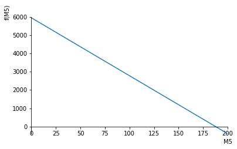

```
[187.737315875614]
```

```python
sym.plot(M2.subs(soln),(M5,0,200))
print(sym.solve(M2.subs(soln),M5))
```

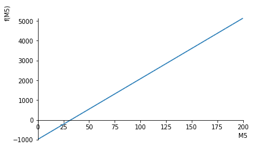

```
[32.2033898305085]
```

```python
sym.plot(M3.subs(soln),(M5,0,200))
print(sym.solve(M3.subs(soln),M5))
```

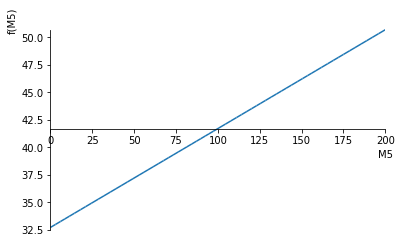

```
[-363.636363636364]
```

```python
sym.plot(M4.subs(soln),(M5,0,200))
print(sym.solve(M4.subs(soln),M5))
```

```python
M5_max = sym.solve(M2.subs(soln))[0]
M5_min = sym.solve(M3.subs(soln))[0]
```

```python
Revenue = 21.48*M2.subs(soln)/100.0 \
          + 16.01*M3.subs(soln)/100.0 \
          + 1.95*M4.subs(soln) \
          + 1.77*M5

print(Revenue)
```

```
0.0362294018424814*M5 + 1184.67735824575
```

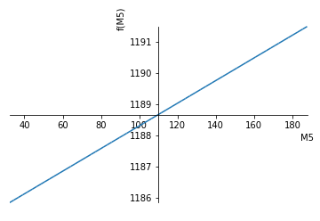

```
<sympy.plotting.plot.Plot at 0x1162a8668>
```

```python
sym.plot(Revenue,(M5,M5_min,M5_max))
```

```python
opt = [sym.Eq(M5_min,M5)]

soln = sym.solve(mbal + specs + opt)

for m in soln.keys():
    print("{0:2s} : {1:8.1f} lb/hr  {2}".format(str(m), soln[m], str(prods[m])))
```

```
M1 :   5000.0 lb/hr  Raw Milk
M2 :   4932.2 lb/hr  Regular Milk Product
M3 :      0.0 lb/hr  Skim Milk Product
M4 :     35.6 lb/hr  Nonfat Dry Milk Product
M5 :     32.2 lb/hr  Butterfat Product
```

Revenue and Milk Price Calculations

```python
print("   Maximum Revenue = ${0:8.2f}/hr".format(Revenue.subs(soln)))
print("Max Raw Milk Price = ${0:8.2f}/lb".format(Revenue.subs(soln)/5000.0))
```

[output not shown]